# STATS 769 Lab 01

## The data

The data are trips on electric scooters and bikes in Austin, Texas. The data came in the form of three CSV files, one per month (form July to September, 2018). Each file contains 5000 trips.

The following code reads the CSV files into R and combines them to create a single data frame.

```r
filenames <- paste0("trips-2018-", 7:9, ".csv")
trips <- do.call(rbind, lapply(filenames, read.csv))
```

A test set was generated by selecting 1000 rows at random from each month. The following code does this by generating 3 sets of 1000 numbers between 1 and 5000 and adding 0, 5000, and 10000 to the sets. The training set consists of the remaining 12000 rows of data.

```r
testIndex <- unlist(lapply(1:3,
                            function(i) {
                                sample(1:5000, 1000) + (i - 1)*5000
                            }))
testTrips <- trips[testIndex, ]
trainTrips <- trips[-testIndex, ]
```

Exploratory plots of trip durations and trip distances show a high right-skew, but log-durations and log-distances are reasonably unimodal and symmetric.

```r
modelTrips <- subset(trainTrips, duration > 0 & distance > 0)
trainDuration <- log(modelTrips$duration)
trainDistance <- log(modelTrips$distance)
```

In order to take logs, it is necessary to remove all non-positive durations and/or distances. This reduces the training set to 11061 observations.

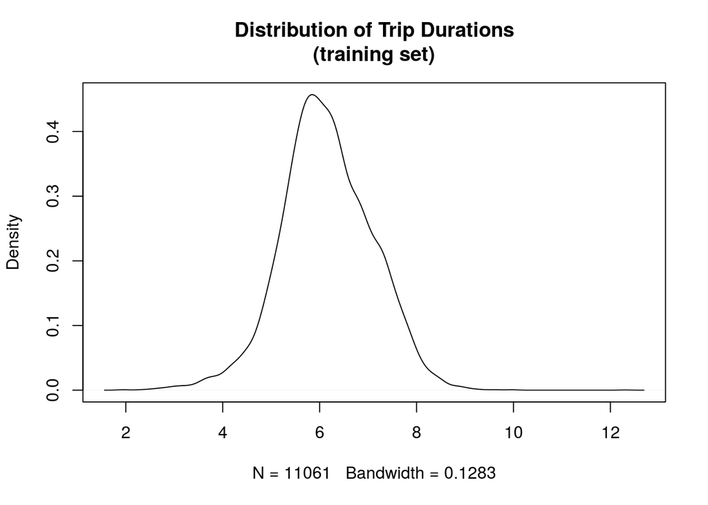

```r
plot(density(trainDuration),
     main="Distribution of Trip Durations\n(training set)")
```

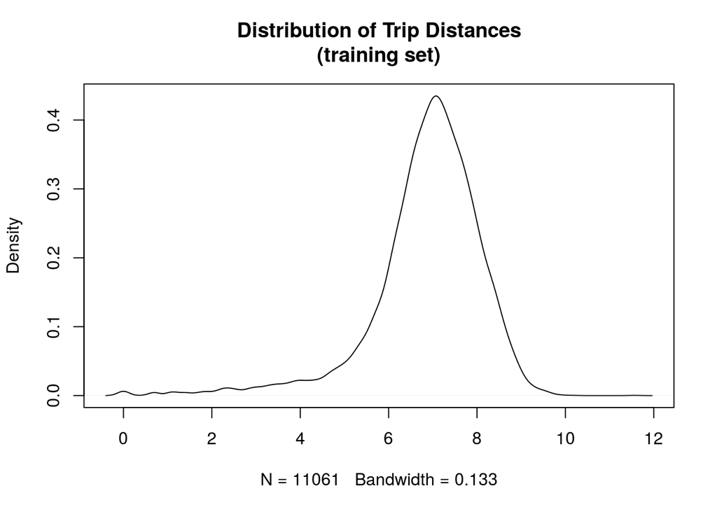

```r
plot(density(trainDistance),
     main="Distribution of Trip Distances\n(training set)")
```

A plot of log-duration against log-distance shows a strong, roughly linear trend, though the relationship breaks down for shorter trips.

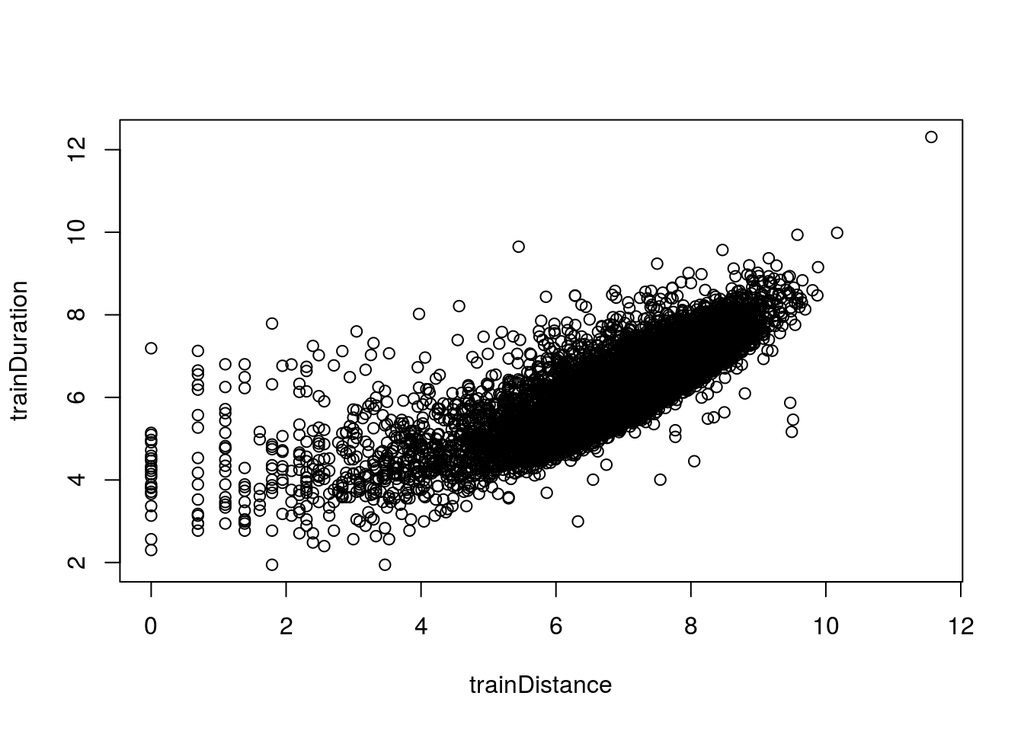

```r
plot(trainDuration ~ trainDistance)
```

## The model

We fit a linear model, plus calculate a simple mean for comparison.

```r
meanFit <- mean(trainDuration)
lmFit <- lm(y ~ x, data.frame(x=trainDistance, y=trainDuration))
```

The linear model provides a lot better fit to the training data than a simple mean, though it under-predicts durations for longer distances. This is a result of the higher variation of durations at short distances “dragging” the fitted line up at the left end.

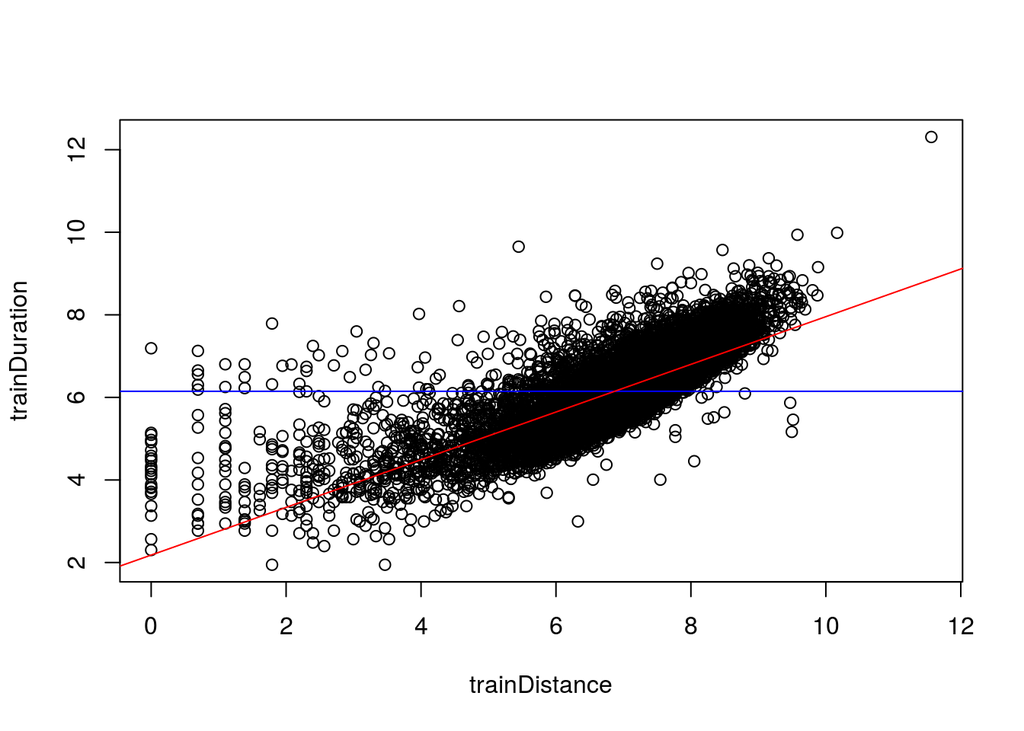

```r
plot(trainDuration ~ trainDistance)
abline(h=meanFit, col="blue")
abline(lmFit, col="red")
```

We prepare and transform the test set using the same subsetting and transformations that we used for the training set.

```r
evalTrips <- subset(testTrips, duration > 0 & distance > 0)
testDistance <- log(evalTrips$distance)
testDuration <- log(evalTrips$duration)
```

This reduces the test set to 2781 observations.

When we look at how the model performs on the test data, we see a very similar result; a straight line is a reasonable fit, but we are not predicting durations as well at long distances.

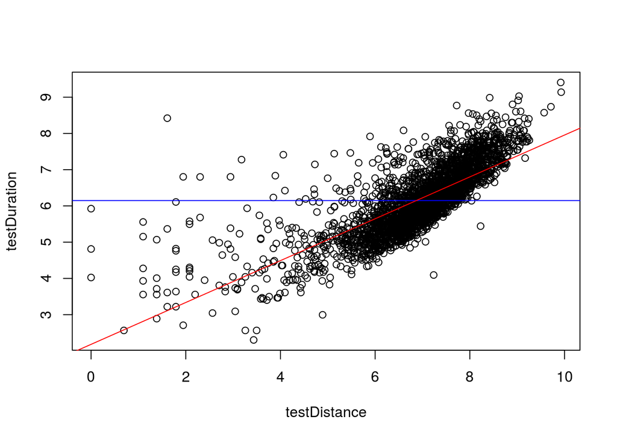

```r
plot(testDuration ~ testDistance)
abline(h=meanFit, col="blue")
abline(lmFit, col="red")
```

The RMSE measure shows clear improvement of a linear model prediction over a simple mean prediction, though there is still a large amount of unexplained variability.

```r
RMSE(meanFit, testDuration)
```

```
## [1] 0.9486317
```

```r
RMSE(predict(lmFit, data.frame(x=testDistance)), testDuration)
```

```
## [1] 0.6099806
```

## Conclusion

The data for this exercise came in a CSV format, which presented no difficulties for importing into R.

Generating a test set was slightly complicated by requiring sub-samples from each month, though this only required standard R data manipulation tools.

We required a log-transformation of both distance and duration variables to obtain unimodal, symmetric data for model fitting. This required excluding non-positive distances and durations (about 8% of the data), which means that our predictive model is only valid for trips that had a non-zero distance or duration. We are unlikely to be predicting zero-distance or zero-duration trips, so this is not a large concern.

We fitted a simple linear regression model, which provided some predictive power, though there are clear opportunities for a more flexible model (or a more robust model) to perform better.